# WEEK 3

Confidence Intervals

Felipe Campelo

## In this lecture…

In this lecture, we’ll go over the main concepts related to quantifying our uncertainty when estimating parameters. More specifically, we will:

- Explore the concept of a confidence intervaland its interpretation in terms of sampling variability.
- Learn how to construct and interpret CIs for a population mean, under different assumptions (normal distribution with known and with unknown, large-sample approximate intervals).
- See how sample size, variability, and confidence level affect the width / precision of the interval.

## Motivation

Last week we discussed concepts related to point estimation of parameters –that is, given a sample, how to get the best possible estimateof the true value of a populational parameter. However, given that point estimates are subject to sampling variability, we know that they will almost always be a bit “off-target”.

We also saw how we can use standard errorsto quantify the uncertainty associated with our estimates. However, although standard errors provide a sense of how much an estimate would vary across repeated samples, it is an incomplete quantification of uncertainty.

What is commonly needed to support decision-making is a range of plausible values for the true population parameter, which captures the real value of the parameter with a known level of confidence.

## Definition

Confidence intervals(CIs) quantify the degree of uncertainty associated with the estimation of population parameterssuch as the mean, variance, proportion, difference of means etc..

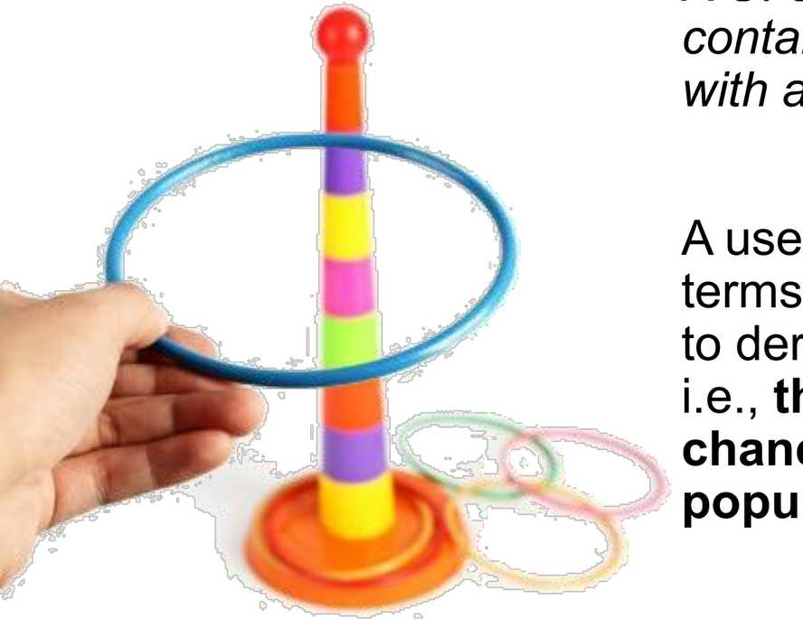

A CI can be defined as an interval that is expected to contain the true value of a given population parameter with a confidence level of ;

A useful way to think about confidence intervals in terms of confidence in the method: The method used to derive the interval has a hit rate of - i.e., the interval generated has a chance of having captured the true value of the population parameter.

## Intuition

[figure not shown]

[figure not shown]

True parameter value (fixed; unknown)

[figure not shown]

Interval (width is determined by factors such as sample size, desired confidence level and variance of the data-generatingprocess.

[figure not shown]

Data-generating process (with its own properties, parameter values, variance etc).

[figure not shown]

## Formalisation

A confidence interval estimate for a given parameter is an interval of the form

where the end-points L and are computed from the sample data.

Given a sample, there is a probability that the CI calculated from it will contain the true value of .

The bounds and are called the lower- and upper-confidence limits.

The quantity is called the confidence level (or confidence coefficient) of the interval.

[figure not shown]

## CI on the mean of a normal variable, known

Suppose that you have a data-generating process that’s distributed according to a normal distribution with known variance and unknown mean , and we get a sample of observations, .

We know that the sample mean will also be normally distributed, with mean and variance .

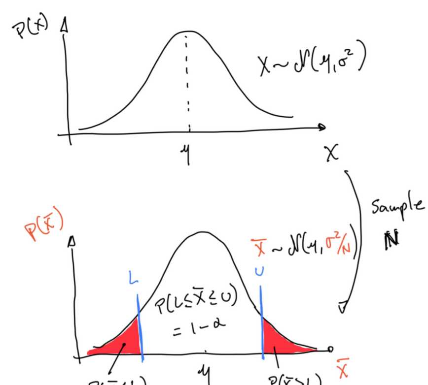

## CI on the mean of a normal variable, known

[figure not shown]

Suppose that you have a data-generating process that’s distributed according to a normal distribution with known variance and unknown mean , and we get a sample of observations, .

We know that the sample mean will also be normally distributed, with mean and variance .

We want to find out what are the values of and such that for any desired confidence level .

[figure not shown]

## CI on the mean of a normal variable, known

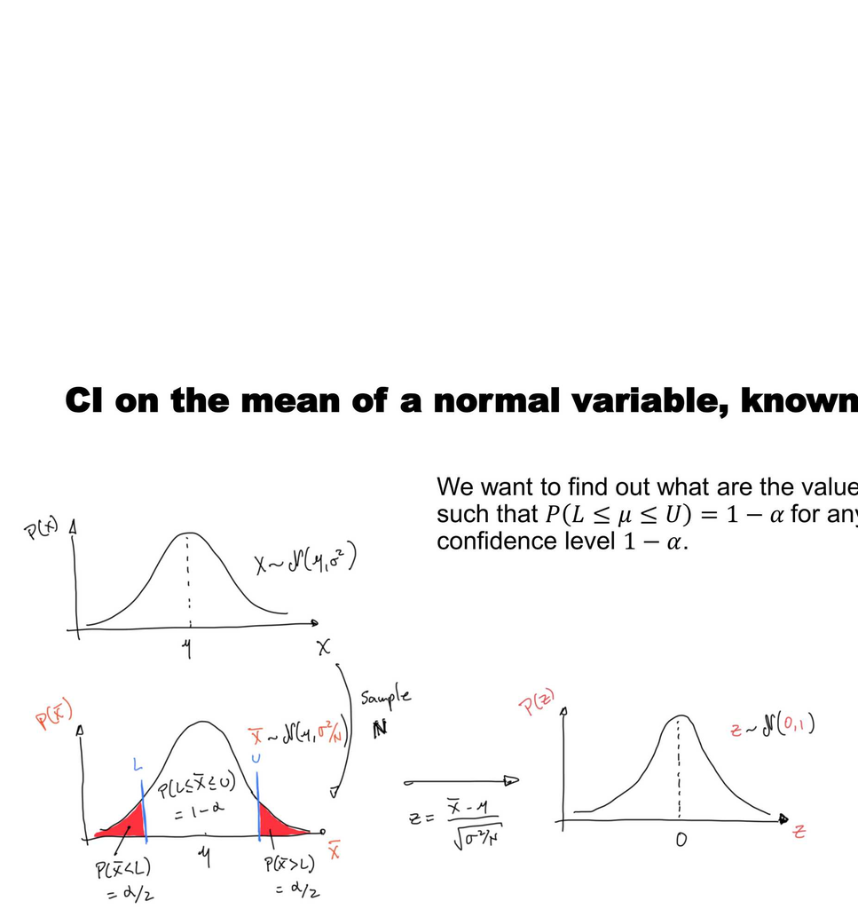

We want to find out what are the values of and such that for any desired confidence level .

## CI on the mean of a normal variable, known

[figure not shown]

We want to find out what are the values of and such that for any desired confidence level .

## CI on the mean of a normal variable, known

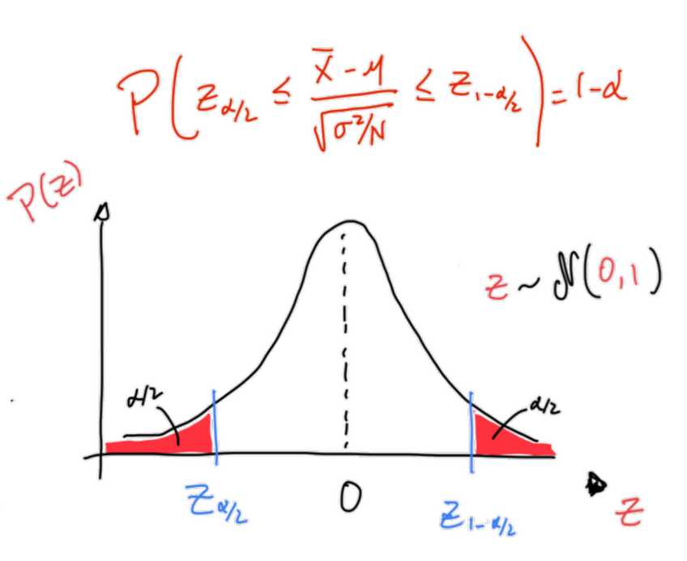

Note that there are infinitely many normal distributions, but only one standard normal, , which has known, well-defined quantiles.

| Cumulative probability (p) | Quantile () |
| --- | --- |
| 0.005 | −2.576 |
| 0.025 | −1.960 |
| 0.05 | −1.645 |
| 0.1 | −1.282 |
| 0.5 | 0 |
| (1-0.1) = 0.9 | 1.282 |
| (1-0.05) = 0.95 | 1.645 |
| (1 - 0.25) = 0.975 | 1.96 |
| (1 - 0.005) = 0.995 | 2.576 |

## CI on the mean of a normal variable, known

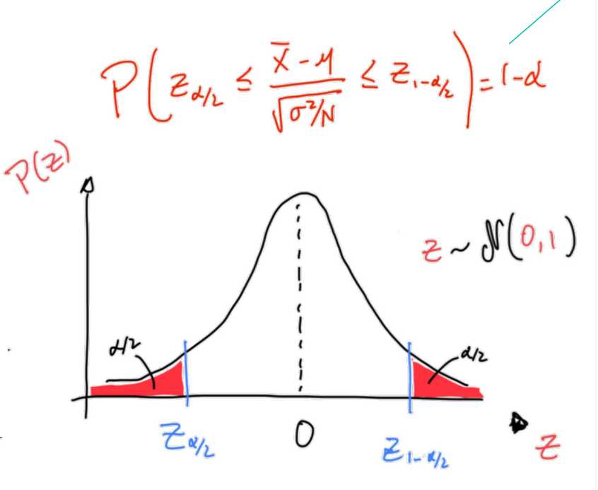

We can manipulate this expression to get:

Since , we have that the interval

captures the true mean with confidence .

[figure not shown]

## Example

Suppose that you get some data related to the daily concentration of Calcium in your local water supply. For each day, the data contains the readings (in mg/litre) of 9 sensors located in the city reservoir. Historical data suggests a known standard deviation of . There is also good evidence in historical data that the distribution of the readings is well-approximated by a normal variable.On a given day, the 9 readings result in a sample mean of 37 mg/l. Based on this data, compute the 99% confidence interval () on the mean concentration on that day. You can approximate .

## Example

Suppose that you get some data related to the daily concentration of Calcium in your local water supply. For each day, the data contains the readings (in mg/litre) of 9 sensors located in the city reservoir. Historical data suggests a known standard deviation of . There is also good evidence in historical data that the distribution of the readings is well-approximated by a normal variable.On a given day, the 9 readings result in a sample mean of 37 mg/l. Based on this data, compute the 99% confidence interval () on the mean concentration on that day. You can approximate .

## Example

Suppose that you get some data related to the daily concentration of Calcium in your local water supply. For each day, the data contains the readings (in mg/litre) of 9 sensors located in the city reservoir. Historical data suggests a known standard deviation of . There is also good evidence in historical data that the distribution of the readings is well-approximated by a normal variable.On a given day, the 9 readings result in a sample mean of 37 mg/l. Based on this data, compute the 99% confidence interval () on the mean concentration on that day. You can approximate .

[figure not shown]

## Confidence level and interval width

Notice that the confidence level is a user-defined parameter. Common choices are 0.95 (95%) or 0.99 (99%). Why don’t people go for 100% confidence?

## Confidence level and interval width

Notice that the confidence level is a user-defined parameter. Common choices are 0.95 (95%) or 0.99 (99%). Why don’t people go for 100% confidence?

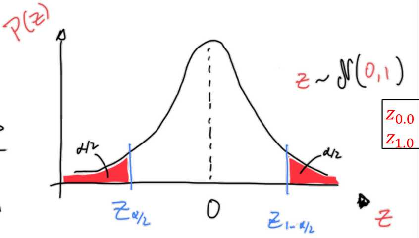

[figure not shown]

## Confidence level and interval width

Notice that the confidence level is a user-defined parameter. Common choices are 0.95 (95%) or 0.99 (99%). Why don’t people go for 100% confidence?

Given a sample, the width of the confidence interval increases as we increase the desired level of confidence - i.e., there is a trade-off between the precision of the interval and its confidence level.

[figure not shown]

## Confidence level and interval width

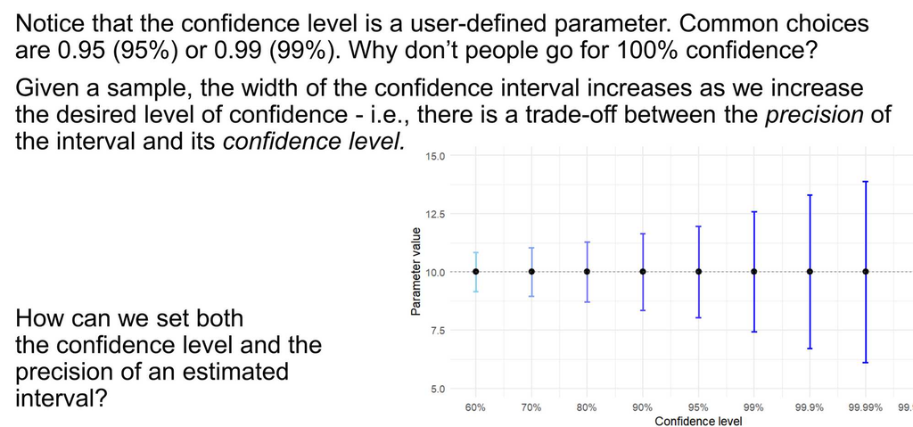

## Sample size calculation

Recall that the confidence interval can be expressed as , which means that the interval half-length (sometimes called the “error” of the estimate) is given by:

If we want a with a predefined half-length , we can easily determine the necessary sample size as:

## Example

Suppose that a real-time data broker wants to estimate the mean number of data requests per user through its API. They want to be able to check if it has changed from the previous month by more than 100 requests/month, at a 95% confidence level. Assume that the standard deviation is known to be close to requests/month. How many users does the company need to sample? You can approximate .

## Example

Suppose that a real-time data broker wants to estimate the mean number of data requests per user through its API. They want to be able to check if it has changed from the previous month by more than 100 requests/month, at a 95% confidence level. Assume that the standard deviation is known to be close to requests/month. How many users does the company need to sample? You can approximate .

## Example

Suppose that a real-time data broker wants to estimate the mean number of data requests per user through its API. They want to be able to check if it has changed from the previous month by more than 100 requests/month, at a 95% confidence level. Assume that the standard deviation is known to be close to requests/month. How many users does the company need to sample? You can approximate .

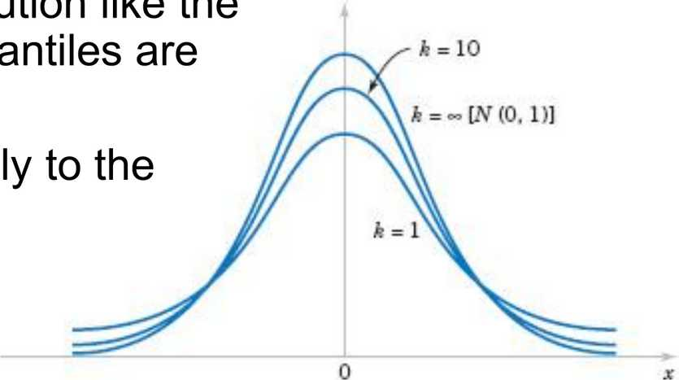

## CI for the mean of a normal variable, unknown

If the variance of the data-generating distribution is unknown, the standard error of the mean is estimated as and we have

distributed according to Student’s distribution with degrees-of-freedom. The distribution is a bell-shaped distribution like the normal, but with heavier tails, meaning that the quantiles are located farther away from the centre.

A confidence interval can be calculated analogously to the previous case:

## Normal vs. t distribution

[figure not shown]

For small sample sizes (= low degrees of freedom) the t-distribution is more “flattened”: heavier tails leading to more conservative (wider) intervals. For large sample sizes, the differences progressively vanish.

[figure not shown]

For smaller sample sizes, t-derived confidence intervals on the mean are wider than the known-variance ones (to account for greater uncertainty in the estimated standard deviation, ).

## Interactive: Shiny App

In Rstudio, open and run the Shiny app “ConfIntShiny.R” (available from Blackboard).

Explore how the different parameters affect the confidence interval half-width.

Also check empirical coverage of the intervals generated.

[figure not shown]

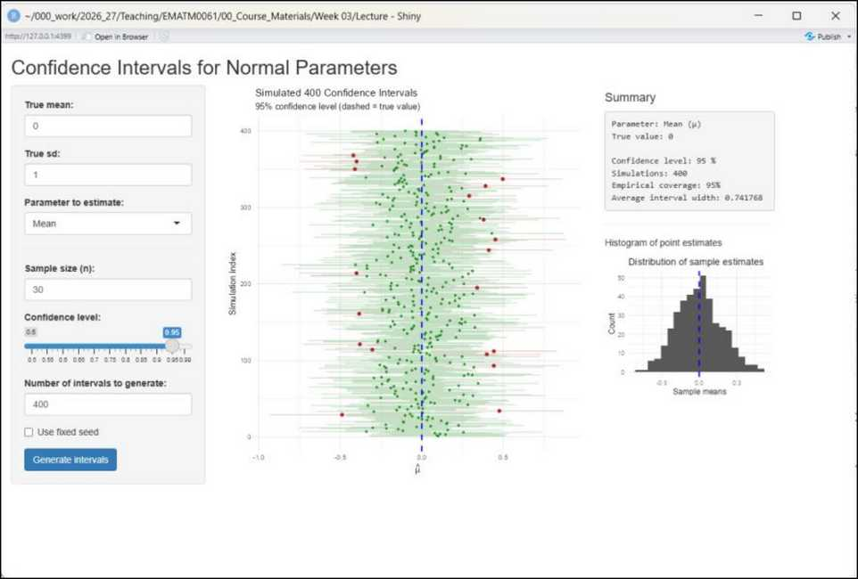

[figure not shown]

## Large-sample CI for , any distribution.

So far, we have assumed that the data-generating distribution is normal. What happens when it is not? Recall the formula for the confidence interval on the mean of a normal variable:

Notice that the connection between the data-generating distribution and the confidence interval formula is mediated by the sample mean . Now, the CLT tells us that, for i.i.d. observations, the sampling distribution of the means converges to a normal distribution regardless of the original data distribution (as long as the mean and variance are finite and the variance is not zero).

[figure not shown]

## Large-sample CI for , any distribution.

This means that, for large , the quantity has a distribution that is very close to the standard normal distribution. Consequently, we can use

to estimate the confidence interval on the mean, and the actual coverage of the interval (i.e., the proportion of times that the interval contain the actual value of the populational mean) will converge to the confidence level .

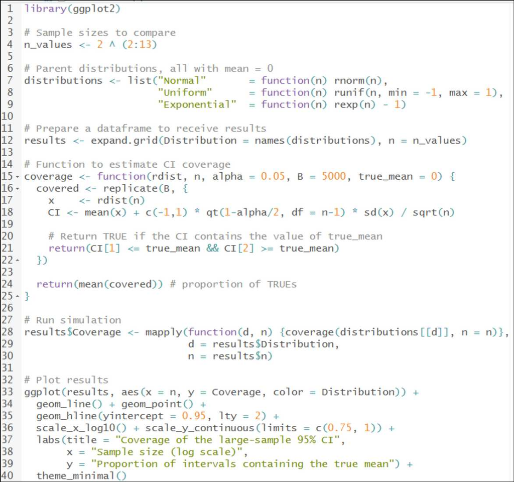

[figure not shown]

## CIs for the difference of two means

One important point that we'll come back to later in the course is that we are often interested in estimating not only parameters from one specific distribution, but differences (or ratios, or sums) of the parameters of two distributions.

For instance, a very common situation in A/B testing involves comparing the mean performance of two different approaches (recall our silly example in week 1). In this case, we're interested in estimating the difference of two means and its associated confidence interval.

[figure not shown]

## Difference of two means

Deriving the expression for the CI on the difference of means for two normal distributions is generally straightforward.

We start from the two distributions and , from which two independent samples of sizes , were taken.

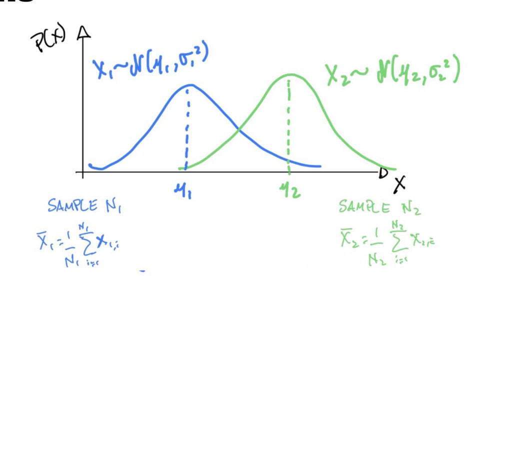

[figure not shown]

## Difference of two means

Deriving the expression for the CI on the difference of means for two normal distributions is generally straightforward.

We start from the two distributions and , from which two independent samples of sizes , were taken.

We know that the sampling distribution of the means will also be normal, with and

[figure not shown]

## Difference of two means

The natural estimator for the difference of two populational means is the difference of the sample means, .

[figure not shown]

## Difference of two means

The natural estimator for the difference of two populational means is the difference of the sample means, .

It is well-known that the difference of two Normal random variables is also Normally distributed.

[figure not shown]

## Difference of two means

We are now at a similar point from when we derived the confidence interval for a single populational mean.

[figure not shown]

## Difference of two means

We are now at a similar point from when we derived the confidence interval for a single populational mean.

The remaining steps are similar to what we did earlier for the CI on a single populational mean.

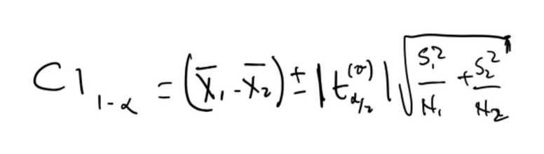

[figure not shown]

## Difference of two means

We are now at a similar point from when we derived the confidence interval for a single populational mean.

The remaining steps are similar to what we did earlier for the CI on a single populational mean.

The only real challenge in the present case is the determination of the number of degrees-of-freedom for the t-distribution, .

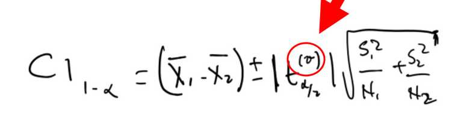

## Difference of two means

The most widely known method to estimate the degrees-of-freedom in the general case of unknown and potentially unequal variances is known as the Welch method.

(Don’t worry too much about the degrees-of-freedom formula: you’ll probably never need to compute it by hand. R can do it for you)

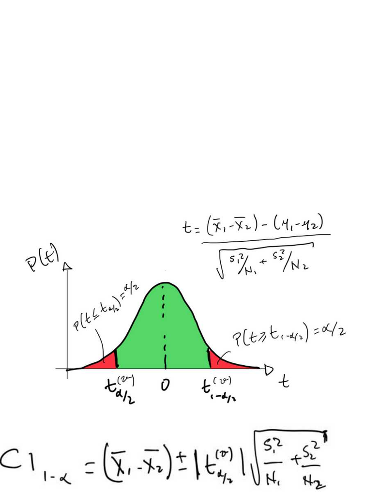

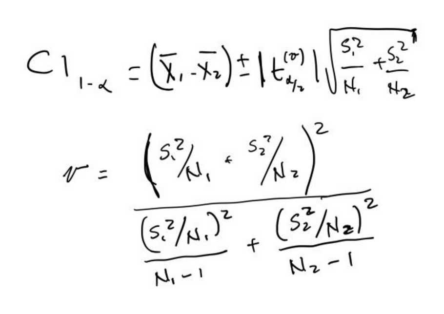

## Example: Resting heart rate

The [National Health and Nutrition Examination Survey](https://www.cdc.gov/nchs/nhanes/index.html) [(NHANES)](https://www.cdc.gov/nchs/nhanes/index.html) is a large, publicly available U.S. health survey that combines questionnaires with actual physical examinations and laboratory measurements.

NHANES provides a lot of measurements of health variables for tens of thousands of participants, which makes it an interesting dataset to explore all sorts of questions.

Today, we’ll use if to check the following question: In non-smoking men aged between 40 and 50 years of age, what is the difference in the mean resting heart rate of people who do not exercise vs. those who do?

[figure not shown]

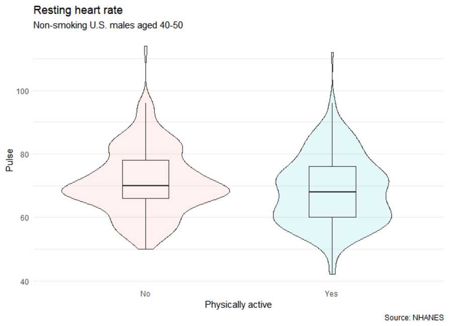

## Example: Resting heart rate

[figure not shown]

## CIs for other parameters / distributions

If your data-generating process follows a known probability distribution, there are often specific formulas to calculate confidence intervals. For large sample sizes, these are often based on the approximate interval template:

For smaller sample sizes, there are distribution-specific formulas or procedures that can usually be easily found. E.g., the exact CI on the variance of a normal distribution can be calculated using:

## CIs for other parameters / distributions

The more general case, in which the data-generating distribution cannot be easily described as a known / canonical random variable, requires distribution-free methods.

There are a few such methods based on sophisticated statistical results, but one of the most common (and most powerful) is called the bootstrap. This method is based on repeated resampling of the available sample and the distribution of an empirical estimate of the sampling distribution of any statistic of interest.

We will discuss the bootstrap in this week’s lab session.

## In this lecture we discussed…

- What confidence intervals represent and how they express uncertainty around sample estimates of parameters.
- How to derive and compute confidence intervals for a population mean under different scenarios.
- The influence of sample size, variability, and confidence level on interval width and precision.

Confidence intervals express estimation uncertainty as a range with a quantified degree of certainty, helping you make statistically sound decisions with a better awareness of the (un)certainty of your estimates.

## Further reading

DC Montgomery, GC Runger, [Applied statistics and probability for engineers, 5](https://bris.on.worldcat.org/oclc/798669665)[th](https://bris.on.worldcat.org/oclc/798669665) [ed.](https://bris.on.worldcat.org/oclc/798669665) [Chapters 8.1-8.5]

- Read the chapter and try to solve the worked examples by yourself.